# PC Practical: Linear regression II

## Exercise 17

The data in the dataset calibration.txt were collected by students at the VIB in a study on the saccharification potential of a wild-type poplar and a transgene CCR poplar. Cellulose is first decomposed by cellulase and beta-glucosidase. The released glucosis in the hydrolised samples is then estimated using a combined enzymatic test, i.e., glucose oxidase type II-S from *Aspergillus niger* (GOD) and peroxidase type II from horseradish (POD) with the chromogen ABTS (2,2’-azino-bis(3-ethylbenzothiazoline-6-sulphonic acid)). The accompanying reactions are for

**GOD: D-glucose + O<sub>2</sub> <—> D-gluconic acid + H<sub>2</sub>O<sub>2</sub>**

and for

**POD: H<sub>2</sub>O<sub>2</sub> + ABTS <—> ABTS<sup>+</sup> + H<sub>2</sub>O.**

GOD catalyses the oxidation of glucose during which H<sub>2</sub>O<sub>2</sub> is released. This H<sub>2</sub>O<sub>2</sub> oxides ABTS in the presence of POD to the green radical cation ABTS<sup>+</sup>. The increase in absorbance for 405 nm was measured for known concentrations of glucose.

Read the data via `read.table`. Change your working directory to the folder where you stored `calibration.txt`.

```r
calib <- read.table("calibration.txt", sep="", header = TRUE)
attach(calib)
```

#### 1. Fit a linear regression model for the absorbance for 405 nm (`A405`) in function of the percentage glucose (`gluc_percent`). Interpret the result.

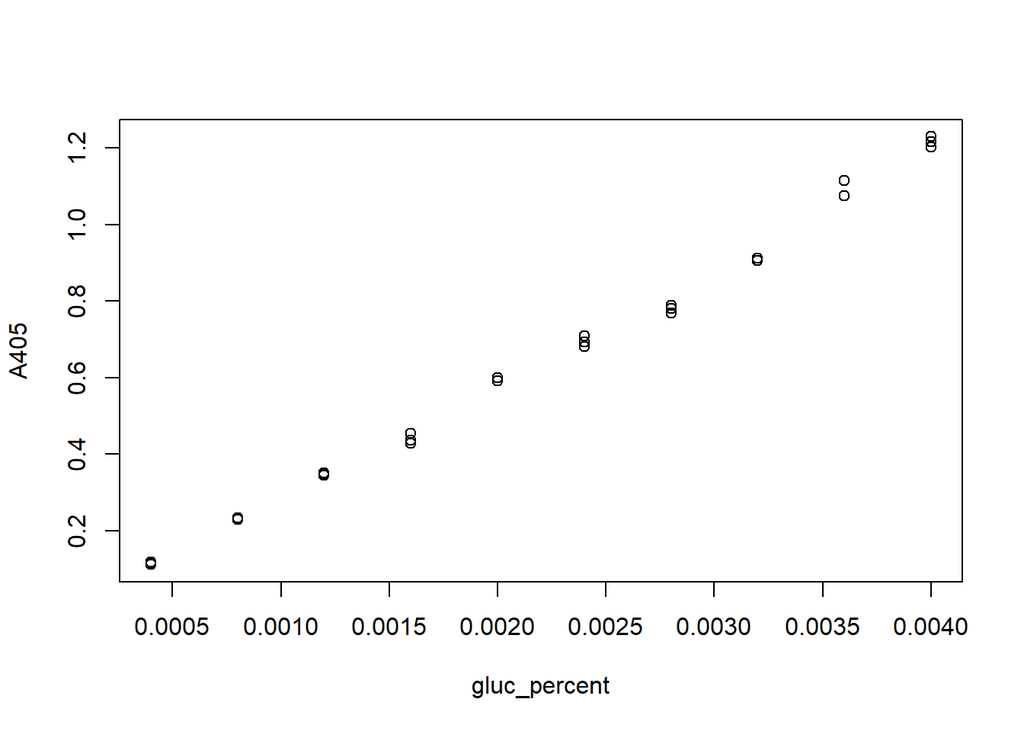

```r
model <- lm(A405 ~ gluc_percent)

plot(A405 ~ gluc_percent)
```

```r
summary(model)
```

```
##
## Call:
## lm(formula = A405 ~ gluc_percent)
##
## Residuals:
##       Min        1Q    Median        3Q       Max
## -0.055891 -0.024989  0.008609  0.014698  0.049788
##
## Coefficients:
##               Estimate Std. Error t value Pr(>|t|)
## (Intercept)   -0.02073    0.01104  -1.879   0.0707 .
## gluc_percent 301.65152    4.44672  67.837   <2e-16 ***
## ---
## Signif. codes:  0 '***' 0.001 '**' 0.01 '*' 0.05 '.' 0.1 ' ' 1
##
## Residual standard error: 0.02798 on 28 degrees of freedom
## Multiple R-squared:  0.994,  Adjusted R-squared:  0.9937
## F-statistic:  4602 on 1 and 28 DF,  p-value: < 2.2e-16
```

```r
confint(model)
```

```
##                     2.5 %       97.5 %
## (Intercept)   -0.04334053 1.873866e-03
## gluc_percent 292.54281486 3.107602e+02
```

#### 2. Compose a calibration curve together with the accompanying 95% confidence intervals. Do the same, but with 95% prediction intervals. Interpret the results.

Since we want to compose a calibration curve, we want to have predictions for each $X$-value. Thus first create a sequence of new data points to predict and then predict the outcome using the linear model.

Take care, when predicting, make sure that either your new data are in a dataframe with column name ‘gluc_percent’ or specifiy this in your prediction step as below.

```r
newx <- seq(min(gluc_percent), max(gluc_percent), length = 1000)
CI <- predict(model, newdata = data.frame(gluc_percent = newx), interval = 'confidence')
PI <- predict(model, newdata = data.frame(gluc_percent = newx), interval = 'prediction')
```

Next plot the curve with confidence and prediction intervals:

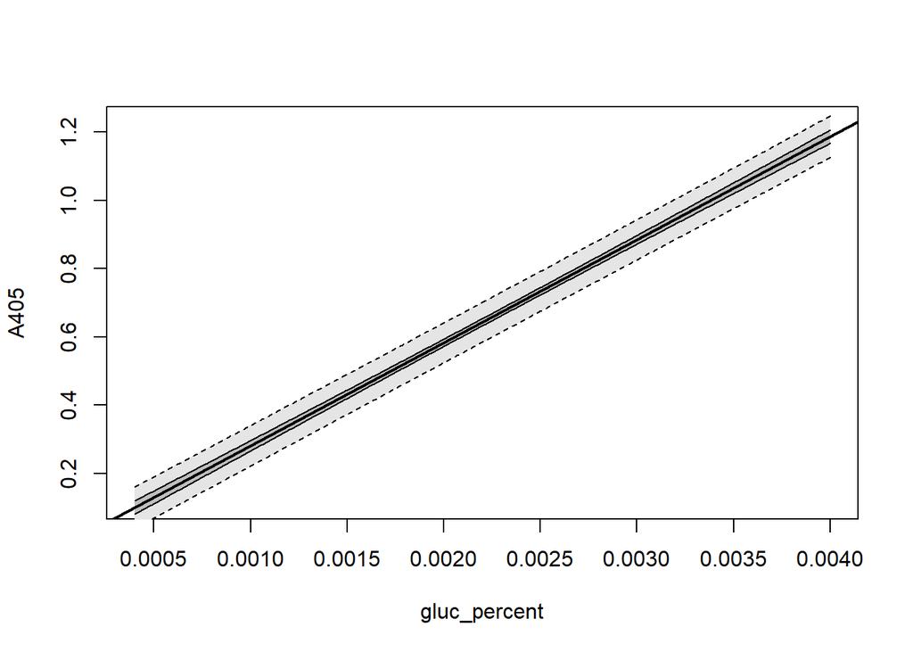

```r
plot(A405 ~ gluc_percent, type = "n")
polygon(c(rev(newx), newx), c(rev(PI[, 3]), PI[, 2]), col = "grey90", border = NA)
lines(newx, PI[, 3], lty = "dashed")
lines(newx, PI[, 2], lty = "dashed")
polygon(c(rev(newx), newx), c(rev(CI[, 3]), CI[, 2]), col = "grey75", border = NA)
lines(newx, CI[, 3], lwd = 1)
lines(newx, CI[, 2], lwd = 1)
abline(model, lwd = 2)
```

The 95% confidence interval contains with 95% probability the true regression line.

The 95% prediction interval contains with 95% probability a random observation of the absorbance for 405 nm, given a certain value for the predictor variable percentage glucose.

#### 3. Verify whether the model describes the data properly. If not, adapt

the model and the obtained calibration curves.

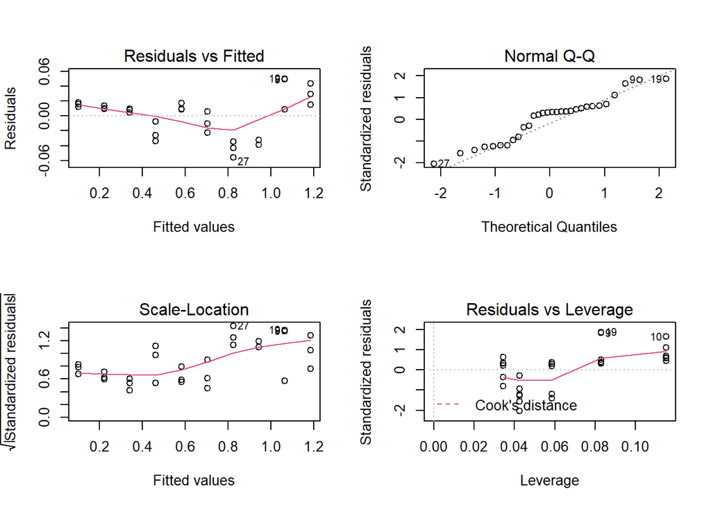

```r
par(mfrow=c(2,2))
plot(model)
```

The linearity assumption does not seem to hold. Also normality and homoscedasticity do not seem to be OK. To solve linearity we can add a quadratic term.

```r
model2 <- lm(A405 ~ gluc_percent + I(gluc_percent^2))
summary(model2)
```

```
##
## Call:
## lm(formula = A405 ~ gluc_percent + I(gluc_percent^2))
##
## Residuals:
##       Min        1Q    Median        3Q       Max
## -0.042755 -0.013843  0.001155  0.013630  0.041030
##
## Coefficients:
##                    Estimate Std. Error t value Pr(>|t|)
## (Intercept)       2.743e-02  1.564e-02   1.754 0.090863 .
## gluc_percent      2.414e+02  1.633e+01  14.781 1.84e-14 ***
## I(gluc_percent^2) 1.368e+04  3.618e+03   3.782 0.000785 ***
## ---
## Signif. codes:  0 '***' 0.001 '**' 0.01 '*' 0.05 '.' 0.1 ' ' 1
##
## Residual standard error: 0.02304 on 27 degrees of freedom
## Multiple R-squared:  0.996,  Adjusted R-squared:  0.9958
## F-statistic:  3401 on 2 and 27 DF,  p-value: < 2.2e-16
```

```r
anova(model, model2)
```

```
## Analysis of Variance Table
##
## Model 1: A405 ~ gluc_percent
## Model 2: A405 ~ gluc_percent + I(gluc_percent^2)
##   Res.Df      RSS Df Sum of Sq      F    Pr(>F)
## 1     28 0.021925
## 2     27 0.014332  1 0.0075928 14.304 0.0007854 ***
## ---
## Signif. codes:  0 '***' 0.001 '**' 0.01 '*' 0.05 '.' 0.1 ' ' 1
```

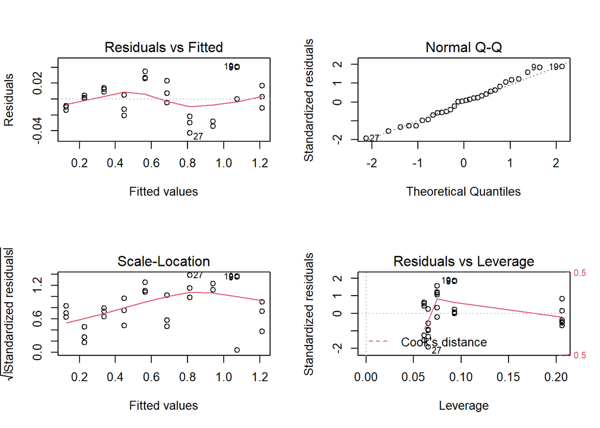

```r
par(mfrow = c(2,  2))
plot(model2)
```

Indeed adding the quadratic term significantly contributes in explaining the variance in the absorbance for 450nm given that the percentage glucose is already in the model.

Linearity: maybe, but let’s try to improve it by adding a cubic term

```r
model3 <- lm(A405 ~ gluc_percent + I(gluc_percent^2) + I(gluc_percent^3))
summary(model3)
```

```
##
## Call:
## lm(formula = A405 ~ gluc_percent + I(gluc_percent^2) + I(gluc_percent^3))
##
## Residuals:
##       Min        1Q    Median        3Q       Max
## -0.033257 -0.016152 -0.001186  0.004581  0.045320
##
## Coefficients:
##                     Estimate Std. Error t value Pr(>|t|)
## (Intercept)       -1.638e-02  2.399e-02  -0.683    0.501
## gluc_percent       3.386e+02  4.495e+01   7.533 5.37e-08 ***
## I(gluc_percent^2) -3.897e+04  2.318e+04  -1.681    0.105
## I(gluc_percent^3)  7.978e+06  3.475e+06   2.296    0.030 *
## ---
## Signif. codes:  0 '***' 0.001 '**' 0.01 '*' 0.05 '.' 0.1 ' ' 1
##
## Residual standard error: 0.02141 on 26 degrees of freedom
## Multiple R-squared:  0.9967, Adjusted R-squared:  0.9963
## F-statistic:  2628 on 3 and 26 DF,  p-value: < 2.2e-16
```

```r
anova(model2, model3)
```

```
## Analysis of Variance Table
##
## Model 1: A405 ~ gluc_percent + I(gluc_percent^2)
## Model 2: A405 ~ gluc_percent + I(gluc_percent^2) + I(gluc_percent^3)
##   Res.Df      RSS Df Sum of Sq      F  Pr(>F)
## 1     27 0.014332
## 2     26 0.011916  1  0.002416 5.2717 0.02999 *
## ---
## Signif. codes:  0 '***' 0.001 '**' 0.01 '*' 0.05 '.' 0.1 ' ' 1
```

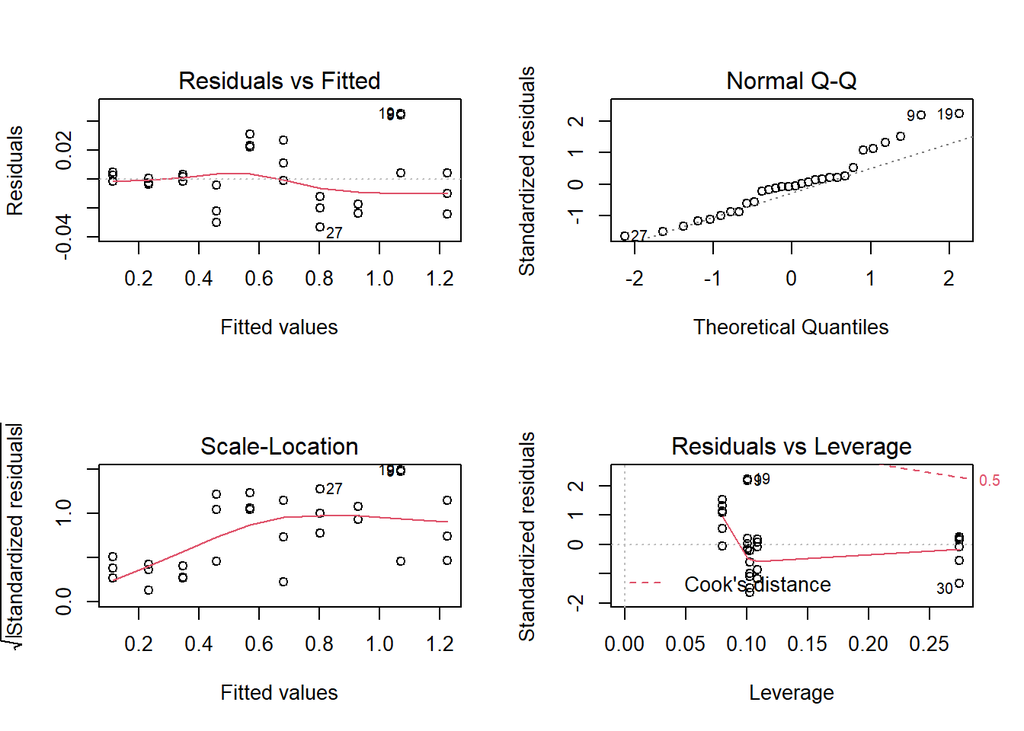

```r
par(mfrow = c(2, 2))
plot(model3)
```

Slight improvement for linearity, but normality became worse. Adding the cubic term significantly contributes in explaining the variance in the absorbance for 450nm given that there is already a first and second order term for percentage glucose in the model, but it is only just significant

What if we add a fourth order term?

```r
model4 <- lm(A405 ~ gluc_percent + I(gluc_percent^2) + I(gluc_percent^3) + I(gluc_percent^4))
summary(model4)
```

```
##
## Call:
## lm(formula = A405 ~ gluc_percent + I(gluc_percent^2) + I(gluc_percent^3) +
##     I(gluc_percent^4))
##
## Residuals:
##       Min        1Q    Median        3Q       Max
## -0.033343 -0.015807 -0.001330  0.004751  0.045950
##
## Coefficients:
##                     Estimate Std. Error t value Pr(>|t|)
## (Intercept)       -1.228e-02  4.163e-02  -0.295   0.7705
## gluc_percent       3.254e+02  1.173e+02   2.774   0.0103 *
## I(gluc_percent^2) -2.695e+04  1.016e+05  -0.265   0.7929
## I(gluc_percent^3)  3.872e+06  3.393e+07   0.114   0.9101
## I(gluc_percent^4)  4.667e+08  3.835e+09   0.122   0.9041
## ---
## Signif. codes:  0 '***' 0.001 '**' 0.01 '*' 0.05 '.' 0.1 ' ' 1
##
## Residual standard error: 0.02183 on 25 degrees of freedom
## Multiple R-squared:  0.9967, Adjusted R-squared:  0.9962
## F-statistic:  1896 on 4 and 25 DF,  p-value: < 2.2e-16
```

```r
anova(model3, model4)
```

```
## Analysis of Variance Table
##
## Model 1: A405 ~ gluc_percent + I(gluc_percent^2) + I(gluc_percent^3)
## Model 2: A405 ~ gluc_percent + I(gluc_percent^2) + I(gluc_percent^3) +
##     I(gluc_percent^4)
##   Res.Df      RSS Df  Sum of Sq      F Pr(>F)
## 1     26 0.011916
## 2     25 0.011909  1 7.0531e-06 0.0148 0.9041
```

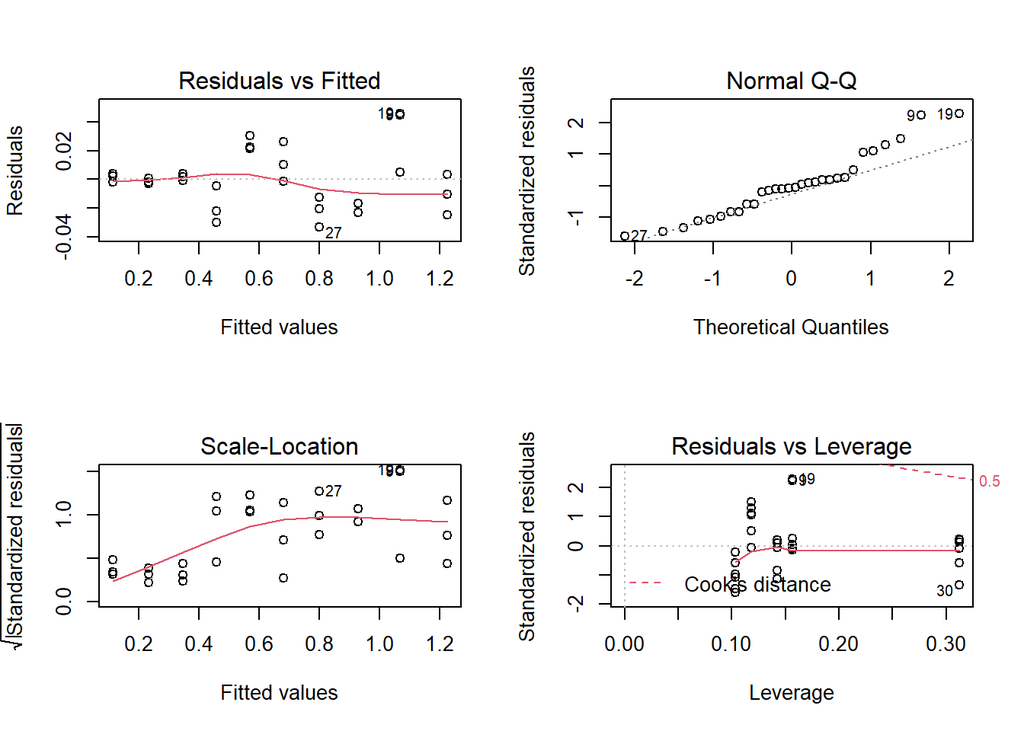

```r
par(mfrow = c(2, 2))
plot(model4)
```

It seems like the fourth order term is not needed. So we continue with the model of degree 3. We’ll try some transformations to improve the normality and homoscedasticity.

```r
model3log <- lm(log(A405) ~ gluc_percent + I(gluc_percent^2) + I(gluc_percent^3))
summary(model3log)
```

```
##
## Call:
## lm(formula = log(A405) ~ gluc_percent + I(gluc_percent^2) + I(gluc_percent^3))
##
## Residuals:
##       Min        1Q    Median        3Q       Max
## -0.089079 -0.028876  0.002154  0.028894  0.075177
##
## Coefficients:
##                     Estimate Std. Error t value Pr(>|t|)
## (Intercept)       -2.886e+00  5.098e-02 -56.603  < 2e-16 ***
## gluc_percent       2.159e+03  9.553e+01  22.601  < 2e-16 ***
## I(gluc_percent^2) -6.348e+05  4.926e+04 -12.887 8.50e-13 ***
## I(gluc_percent^3)  7.244e+07  7.385e+06   9.809 3.16e-10 ***
## ---
## Signif. codes:  0 '***' 0.001 '**' 0.01 '*' 0.05 '.' 0.1 ' ' 1
##
## Residual standard error: 0.0455 on 26 degrees of freedom
## Multiple R-squared:  0.9964, Adjusted R-squared:  0.996
## F-statistic:  2393 on 3 and 26 DF,  p-value: < 2.2e-16
```

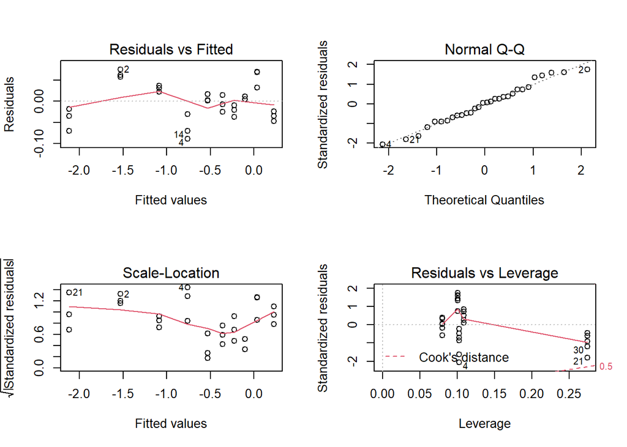

```r
par(mfrow = c(2, 2))
plot(model3log)
```

```r
model3inv <- lm(1/A405 ~ gluc_percent + I(gluc_percent^2) + I(gluc_percent^3))
summary(model3inv)
```

```
##
## Call:
## lm(formula = 1/A405 ~ gluc_percent + I(gluc_percent^2) + I(gluc_percent^3))
##
## Residuals:
##      Min       1Q   Median       3Q      Max
## -0.83134 -0.27029  0.06618  0.28593  0.74009
##
## Coefficients:
##                     Estimate Std. Error t value Pr(>|t|)
## (Intercept)        1.255e+01  4.564e-01  27.509  < 2e-16 ***
## gluc_percent      -1.270e+04  8.552e+02 -14.851 3.25e-14 ***
## I(gluc_percent^2)  4.688e+06  4.410e+05  10.630 5.85e-11 ***
## I(gluc_percent^3) -5.657e+08  6.611e+07  -8.557 4.89e-09 ***
## ---
## Signif. codes:  0 '***' 0.001 '**' 0.01 '*' 0.05 '.' 0.1 ' ' 1
##
## Residual standard error: 0.4073 on 26 degrees of freedom
## Multiple R-squared:  0.9725, Adjusted R-squared:  0.9693
## F-statistic: 306.1 on 3 and 26 DF,  p-value: < 2.2e-16
```

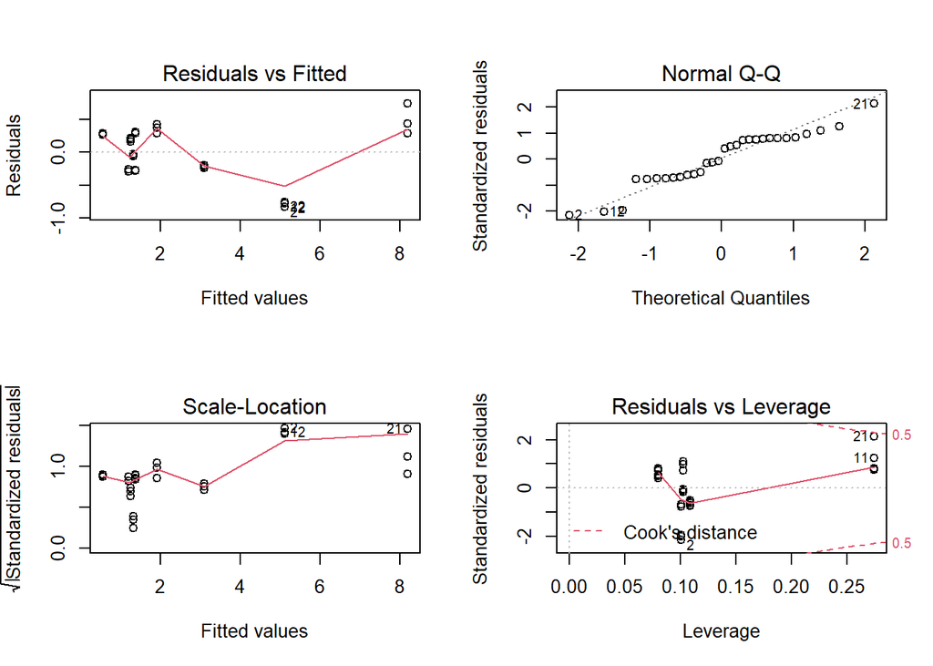

```r
par(mfrow = c(2, 2))
plot(model3inv)
```

```r
model3sqrt <- lm(sqrt(A405) ~ gluc_percent + I(gluc_percent^2) + I(gluc_percent^3))
summary(model3sqrt)
```

```
##
## Call:
## lm(formula = sqrt(A405) ~ gluc_percent + I(gluc_percent^2) +
##     I(gluc_percent^3))
##
## Residuals:
##        Min         1Q     Median         3Q        Max
## -0.0246341 -0.0072987 -0.0003451  0.0061249  0.0250845
##
## Coefficients:
##                     Estimate Std. Error t value Pr(>|t|)
## (Intercept)        1.837e-01  1.405e-02  13.076 6.11e-13 ***
## gluc_percent       4.351e+02  2.632e+01  16.528 2.61e-15 ***
## I(gluc_percent^2) -9.692e+04  1.357e+04  -7.140 1.39e-07 ***
## I(gluc_percent^3)  1.151e+07  2.035e+06   5.655 6.02e-06 ***
## ---
## Signif. codes:  0 '***' 0.001 '**' 0.01 '*' 0.05 '.' 0.1 ' ' 1
##
## Residual standard error: 0.01254 on 26 degrees of freedom
## Multiple R-squared:  0.9975, Adjusted R-squared:  0.9972
## F-statistic:  3499 on 3 and 26 DF,  p-value: < 2.2e-16
```

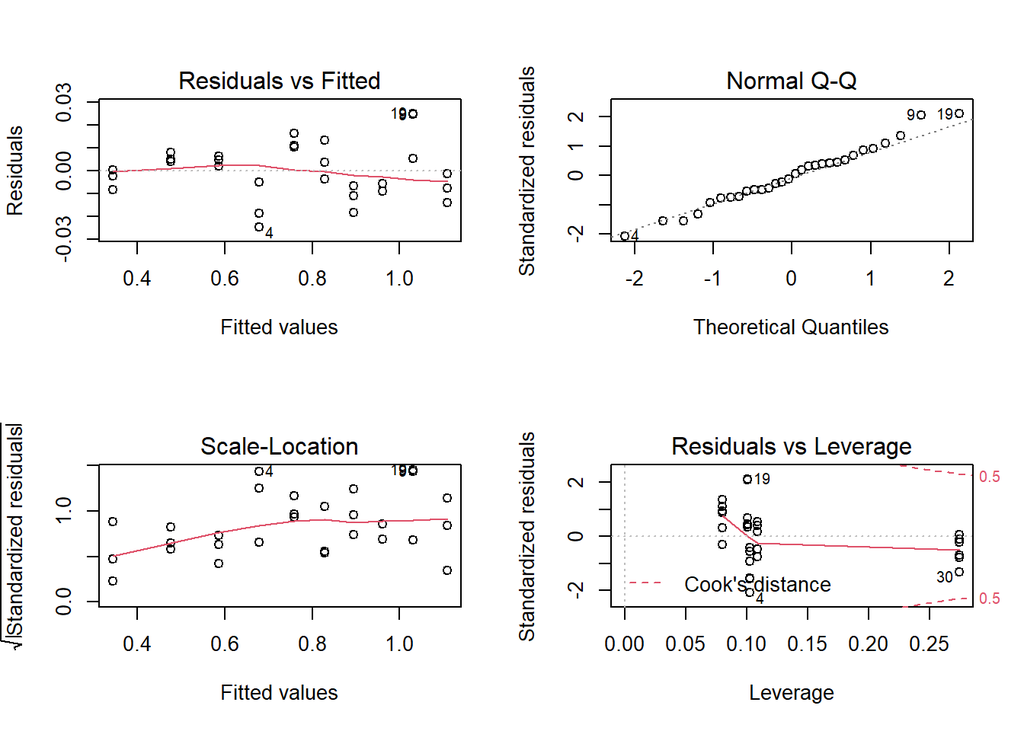

```r
par(mfrow = c(2, 2))
plot(model3sqrt)
```

We choose the 3rd order model with sqrt-transformation.

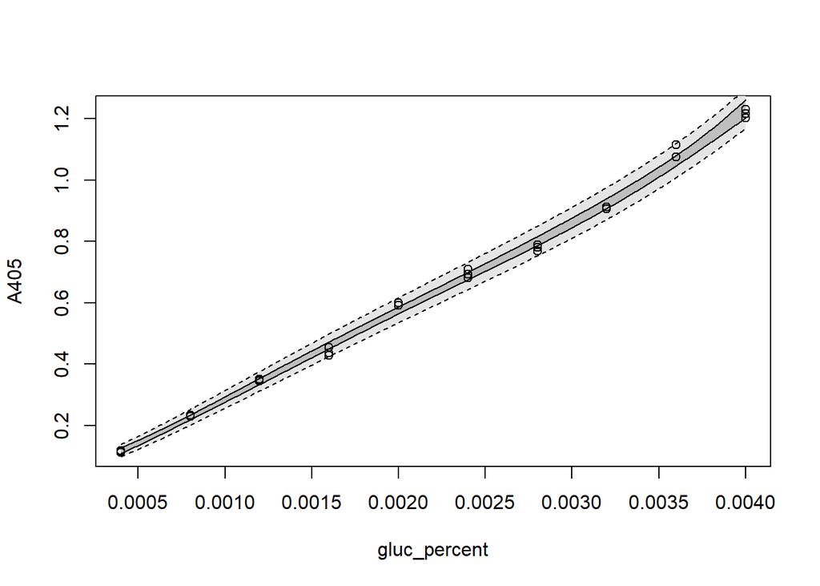

```r
newx <- seq(min(gluc_percent), max(gluc_percent), length = 1000)
CI <- predict(model3sqrt, newdata = data.frame(gluc_percent = newx), interval = 'confidence')^2
PI <- predict(model3sqrt, newdata = data.frame(gluc_percent = newx), interval = 'prediction')^2

plot(A405 ~ gluc_percent, type = "n")
polygon(c(rev(newx), newx), c(rev(PI[, 3]), PI[, 2]), col = "grey90", border = NA)
lines(newx, PI[, 3], lty = "dashed")
lines(newx, PI[, 2], lty = "dashed")
polygon(c(rev(newx), newx), c(rev(CI[, 3]), CI[, 2]), col = "grey75", border = NA)
lines(newx, CI[, 3], lwd = 1)
lines(newx, CI[, 2], lwd = 1)
points(A405 ~ gluc_percent)
```

## Exercise 18

In a study of Lewis (Lewis et al., 1937) that basal metabolism of 50 different boys was measured in calories per hour while they were lying still on a bed in a closed room. Their ages varied from 32 to 152 months. Also their weight and height were measured.

The dataset metadata.txt contains thus the variables:

- **age**: age in month
- **weight**: weight in kg
- **height**: height in cm
- **meta**: metabolism in calories per hour (on logarithmic scale (-1))

```r
metadata <- read.table("metadata.txt", sep="", header = TRUE)
attach(metadata)
```

To not make interpretations needlessly complex: `meta’ is the metabolism in calories per hour on a logarithmic scale, and without the factor “-1”.

#### 1. Find a best model to predict the mean metabolism in function of weight, height and age.

**Use forward selection to find the optimal model**

…

What about quadratic effects?

```r
model7 <- lm(meta ~ height + weight + age + I(age^2)); summary(model7)
```

```
##
## Call:
## lm(formula = meta ~ height + weight + age + I(age^2))
##
## Residuals:
##      Min       1Q   Median       3Q      Max
## -0.04942 -0.01177  0.00030  0.01366  0.03857
##
## Coefficients:
##               Estimate Std. Error t value Pr(>|t|)
## (Intercept)  3.274e-01  8.083e-02   4.050 0.000200 ***
## height       3.625e-04  1.262e-03   0.287 0.775175
## weight       6.017e-03  1.608e-03   3.742 0.000515 ***
## age          2.547e-03  1.000e-03   2.547 0.014362 *
## I(age^2)    -1.234e-05  3.969e-06  -3.108 0.003257 **
## ---
## Signif. codes:  0 '***' 0.001 '**' 0.01 '*' 0.05 '.' 0.1 ' ' 1
##
## Residual standard error: 0.02292 on 45 degrees of freedom
## Multiple R-squared:  0.8985, Adjusted R-squared:  0.8895
## F-statistic:  99.6 on 4 and 45 DF,  p-value: < 2.2e-16
```

…

```r
model8 <- lm(meta ~ weight + age + I(age^2)); summary(model8)
```

```
##
## Call:
## lm(formula = meta ~ weight + age + I(age^2))
##
## Residuals:
##       Min        1Q    Median        3Q       Max
## -0.048337 -0.011677  0.000364  0.014493  0.038488
##
## Coefficients:
##               Estimate Std. Error t value Pr(>|t|)
## (Intercept)  3.498e-01  2.111e-02  16.571  < 2e-16 ***
## weight       6.363e-03  1.054e-03   6.038 2.54e-07 ***
## age          2.786e-03  5.482e-04   5.083 6.65e-06 ***
## I(age^2)    -1.312e-05  2.854e-06  -4.598 3.34e-05 ***
## ---
## Signif. codes:  0 '***' 0.001 '**' 0.01 '*' 0.05 '.' 0.1 ' ' 1
##
## Residual standard error: 0.02269 on 46 degrees of freedom
## Multiple R-squared:  0.8983, Adjusted R-squared:  0.8917
## F-statistic: 135.5 on 3 and 46 DF,  p-value: < 2.2e-16
```

Are there other significant quadratic effects?

```r
model9 <- lm(meta ~ weight + I(weight^2) + age + I(age^2)); summary(model9)
```

```
##
## Call:
## lm(formula = meta ~ weight + I(weight^2) + age + I(age^2))
##
## Residuals:
##       Min        1Q    Median        3Q       Max
## -0.047071 -0.012129  0.000799  0.017461  0.039488
##
## Coefficients:
##               Estimate Std. Error t value Pr(>|t|)
## (Intercept)  3.920e-01  4.364e-02   8.982 1.34e-11 ***
## weight       4.694e-04  5.439e-03   0.086 0.931613
## I(weight^2)  1.006e-04  9.107e-05   1.104 0.275275
## age          3.543e-03  8.769e-04   4.041 0.000205 ***
## I(age^2)    -1.649e-05  4.173e-06  -3.952 0.000271 ***
## ---
## Signif. codes:  0 '***' 0.001 '**' 0.01 '*' 0.05 '.' 0.1 ' ' 1
##
## Residual standard error: 0.02263 on 45 degrees of freedom
## Multiple R-squared:  0.901,  Adjusted R-squared:  0.8922
## F-statistic: 102.4 on 4 and 45 DF,  p-value: < 2.2e-16
```

…

Are there significant interactions?

```r
modelB <- lm(meta ~ weight + age + I(age^2) + height:age + height:I(age^2))
summary(modelB)
```

```
##
## Call:
## lm(formula = meta ~ weight + age + I(age^2) + height:age + height:I(age^2))
##
## Residuals:
##       Min        1Q    Median        3Q       Max
## -0.046003 -0.010673  0.000507  0.016418  0.041912
##
## Coefficients:
##                   Estimate Std. Error t value Pr(>|t|)
## (Intercept)      2.573e-01  6.148e-02   4.184 0.000135 ***
## weight           6.779e-03  1.612e-03   4.206 0.000126 ***
## age              9.764e-03  4.282e-03   2.280 0.027480 *
## I(age^2)        -6.635e-05  3.301e-05  -2.010 0.050558 .
## age:height      -4.117e-05  2.650e-05  -1.554 0.127441
## I(age^2):height  3.455e-07  2.094e-07   1.650 0.106055
## ---
## Signif. codes:  0 '***' 0.001 '**' 0.01 '*' 0.05 '.' 0.1 ' ' 1
##
## Residual standard error: 0.0225 on 44 degrees of freedom
## Multiple R-squared:  0.9043, Adjusted R-squared:  0.8935
## F-statistic:  83.2 on 5 and 44 DF,  p-value: < 2.2e-16
```

```r
modelC <- lm(meta ~ weight + age + I(age^2) + height:age)
summary(modelC)
```

```
##
## Call:
## lm(formula = meta ~ weight + age + I(age^2) + height:age)
##
## Residuals:
##       Min        1Q    Median        3Q       Max
## -0.048135 -0.012153  0.000181  0.015145  0.038062
##
## Coefficients:
##               Estimate Std. Error t value Pr(>|t|)
## (Intercept)  3.447e-01  3.173e-02  10.864 3.64e-14 ***
## weight       6.631e-03  1.640e-03   4.044 0.000203 ***
## age          3.054e-03  1.366e-03   2.236 0.030329 *
## I(age^2)    -1.238e-05  4.503e-06  -2.749 0.008572 **
## age:height  -2.773e-06  1.292e-05  -0.215 0.830990
## ---
## Signif. codes:  0 '***' 0.001 '**' 0.01 '*' 0.05 '.' 0.1 ' ' 1
##
## Residual standard error: 0.02292 on 45 degrees of freedom
## Multiple R-squared:  0.8984, Adjusted R-squared:  0.8894
## F-statistic: 99.51 on 4 and 45 DF,  p-value: < 2.2e-16
```

…

#### 2. Interpret the estimated parameters in your final model, and interpet the multiple correlation coefficient.

```r
finalmodel <- model8
summary(finalmodel)
```

```
##
## Call:
## lm(formula = meta ~ weight + age + I(age^2))
##
## Residuals:
##       Min        1Q    Median        3Q       Max
## -0.048337 -0.011677  0.000364  0.014493  0.038488
##
## Coefficients:
##               Estimate Std. Error t value Pr(>|t|)
## (Intercept)  3.498e-01  2.111e-02  16.571  < 2e-16 ***
## weight       6.363e-03  1.054e-03   6.038 2.54e-07 ***
## age          2.786e-03  5.482e-04   5.083 6.65e-06 ***
## I(age^2)    -1.312e-05  2.854e-06  -4.598 3.34e-05 ***
## ---
## Signif. codes:  0 '***' 0.001 '**' 0.01 '*' 0.05 '.' 0.1 ' ' 1
##
## Residual standard error: 0.02269 on 46 degrees of freedom
## Multiple R-squared:  0.8983, Adjusted R-squared:  0.8917
## F-statistic: 135.5 on 3 and 46 DF,  p-value: < 2.2e-16
```

- 1. Interpretation of the weight parameter estimate:

…

- 2. Interpretation of the age parameter estimate:

The quadratic term makes it difficult to interpret the main effect and the quadratic effect of age separately, but we can interpret the terms together.

- Consider two ages $l$ and $l+1$.
- $\hat{\beta_1}$ is the estimated main effect of age.
- $\hat{\beta_2}$ is the estimated quadratic effect of age.
- $\hat{\beta_2}$ is the estimated effect of weight.

When we keep the predictor variable “weight” constant at the value $g$, then:

$\widehat{meta(l)} = \hat{\beta_2} l^2 + \hat{\beta_1} l + \hat{\beta_3} g$

and

$\widehat{meta(l+1)} = \hat{\beta_2} (l+1)^2 + \hat{\beta_1} (l+1) + \hat{\beta_3} g$

$= \hat{\beta_2} (l^2+2l+1) + \hat{\beta_1} (l+1) + \hat{\beta_3} g$

$= \hat{\beta_2} l^2 + 2 \hat{\beta_2} l+ \hat{\beta_2} + \hat{\beta_1} l + \hat{\beta_1} + \hat{\beta_3} g$

When we substract these from each other, we get:

$\widehat{meta(l+1)} - \widehat{meta(l)} = (\hat{\beta_2} l^2 + 2 \hat{\beta_2} l+ \hat{\beta_2} + \hat{\beta_1} l + \hat{\beta_1} + \hat{\beta_3} g) - (\hat{\beta_2} l^2 + \hat{\beta_1} l + \hat{\beta_3} g)$

$= \hat{\beta_2} l^2 + 2 \hat{\beta_2} l+ \hat{\beta_2} + \hat{\beta_1} l + \hat{\beta_1} + \hat{\beta_3} g - \hat{\beta_2} l^2 - \hat{\beta_1} l - \hat{\beta_3} g$

$= 2 \hat{\beta_2} l+ \hat{\beta_2} + \hat{\beta_1}$

So the increase depends on the value of the “age” variable $l$.

If we plug in the values $\hat{\beta_1} = 2.786*10^{-03}$ and $\hat{\beta_2} = -1.312*10^{-05}$, we get:

$\widehat{meta(l+1)} - \widehat{meta(l)} = -2.624*10^{-05} l - 1.312*10^{-05} + 2.786*10^{-03}$

$= -2.6*10^{-05} l + 0.0028$

Interpretation:

**Interpretation on the original scale:**

…

**Interpret the multiple correlation coefficient**

…

#### 3. Make appropriate QQ-plots and residual plots to assess the final model

fit. Interpret the figures and explain for each figure what any possible deviation represents.

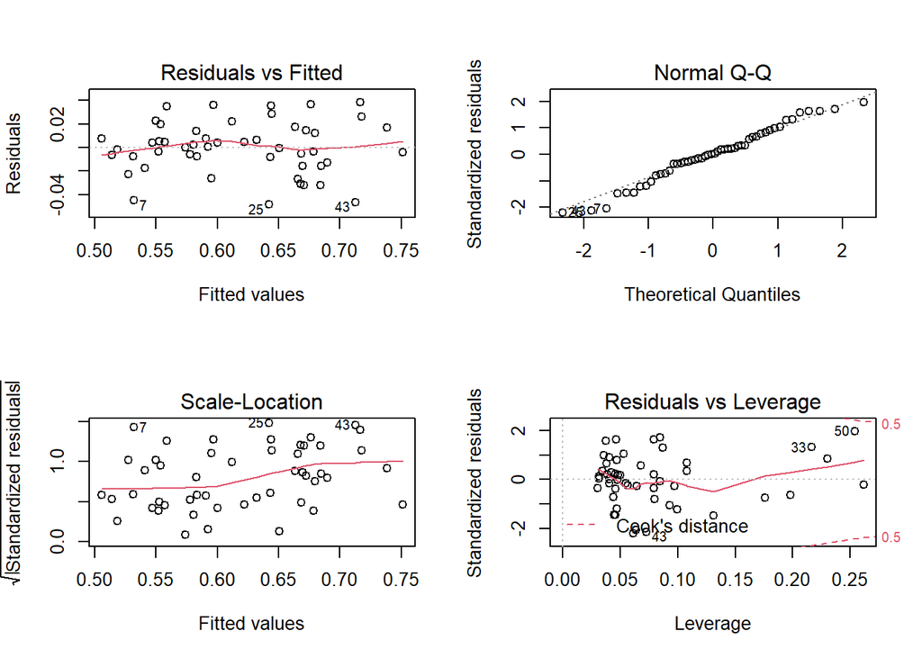

```r
par(mfrow=c(2,2))
plot(finalmodel)
```

Interpretation:

1. Upper left: …
2. Lower left: …
3. Upper right: …
4. Lower right: This graph shows the standardised residuals plotted against the leverage. There are three important things you can deduce from this graph:
   1. The leverage is a measure for the potential of the data point to influence the parameter estimates, if the observation would be shifted in the y-direction by one unit. It indicates which observations are extreme in terms of the predictors. The leverage is considered extreme if it is higher than $2p/n = 2*4/50 = 0.16$. There are quite some points which have an extreme leverage.
   2. (Standardized) residuals indicate how extreme observations are in terms of the response variable. Residuals are considered extreme if the studentized residuals (a similar transformation as standardized residuals) surpasses $1.96*\hat{\sigma}$, where $\hat{\sigma}$ is the residual standard deviation.
   3. This graph also shows the contours for the Cook’s distance equal to 0.5 and 1. Points with a high Cook’s Distance have a high influence on the estimated coefficients and so also on the predictions. They are considered extreme if they pass the 50% percentile of a $F_{p,n-p}$-distribution. The 50% percentile of a $F_{4,46}$-distribution is equal to 0.85. There are no points with an extreme Cook’s Distance.

#### 4. Investigate if the data of certain boys have a large influence on all the fitted values and coefficients. If necessary adjust the model.

Do the data of certain boys have and extreme influence on all the fitted values and coefficients: Cook’s Distance (interpretation, see last question):

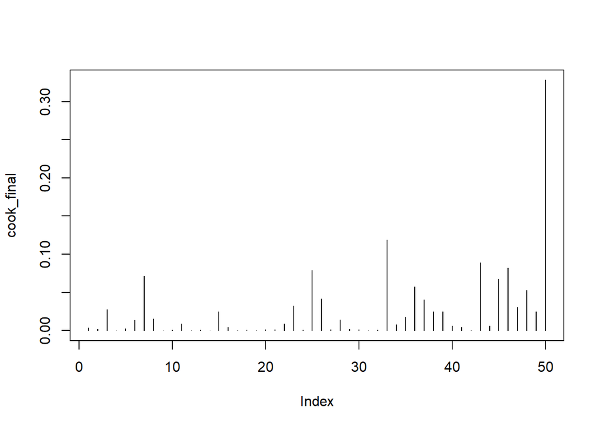

```r
par(mfrow=c(1,1))
cook_final <- cooks.distance(finalmodel)
plot(cook_final,type='h')
```

```r
p <- length(coef(finalmodel))
n <- nrow(metadata)
fquantile <- qf(0.5,df1=p,df2=n-p) #Threshold for Cook's Distance
all(cook_final < fquantile) #TRUE => All Cook's Distances are smaller then the 50% percentile of $F(p,n-p)$-distribution
```

```
## [1] TRUE
```

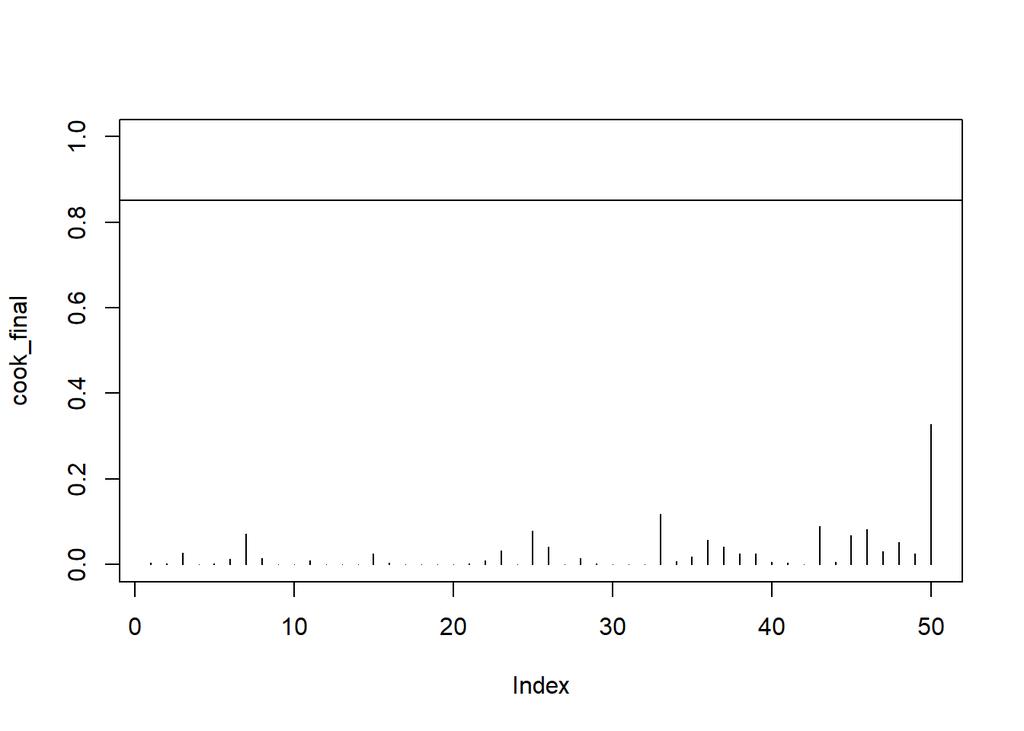

```r
plot(cook_final,type='h',ylim=c(0,1))
abline(h=qf(0.5,df1=p,df2=n-p))
```

Do the data of certain boys have an extreme infuence on certain coefficients?

```r
#dfbetas
dfbeta_finalmodel <- dfbetas(finalmodel)
treshold <- 2 / sqrt(n) #Relatively large dataset, we can use 2 / sqrt(n) as the critical value for DFBETAS
all(dfbeta_finalmodel > treshold) #FALSE => some DFBETAS are larger than the critical value
```

```
## [1] FALSE
```

```r
which(dfbeta_finalmodel[,"(Intercept)"] > treshold) #intercept
```

```
## 25 50
## 25 50
```

```r
which(dfbeta_finalmodel[,"weight"] > treshold) #weight
```

```
## 26 33 46
## 26 33 46
```

```r
which(dfbeta_finalmodel[,"age"] > treshold) #age
```

```
##  7 36 37
##  7 36 37
```

```r
which(dfbeta_finalmodel[,"I(age^2)"] > treshold) #age^2
```

```
## 25 50
## 25 50
```

What we did here was to check, for each parameter separately, which observations have an extreme influence on that parameter. We verify if some observations reoccur several times, because this would mean they have a strong influence on multiple parameters. Observations 25 and 50 have a strong influence on both the intercept and the quadratic effect of age.

```r
metadata[c(25,50),]
```

```
##    age   weight   height  meta
## 25  73 25.00345 125.3141 0.594
## 50 152 38.72576 148.9361 0.755
```

What if we fit the same model without these observations?

```r
metadata2 <- metadata[-c(25,50),]
modelWithout <- lm(metadata2$meta ~ metadata2$weight + metadata2$age + I(metadata2$age^2))
summary(modelWithout)
```

```
##
## Call:
## lm(formula = metadata2$meta ~ metadata2$weight + metadata2$age +
##     I(metadata2$age^2))
##
## Residuals:
##       Min        1Q    Median        3Q       Max
## -0.044212 -0.009552  0.000115  0.012661  0.042265
##
## Coefficients:
##                      Estimate Std. Error t value Pr(>|t|)
## (Intercept)         3.332e-01  2.007e-02  16.601  < 2e-16 ***
## metadata2$weight    6.457e-03  9.853e-04   6.553 5.18e-08 ***
## metadata2$age       3.287e-03  5.395e-04   6.093 2.46e-07 ***
## I(metadata2$age^2) -1.650e-05  2.880e-06  -5.729 8.43e-07 ***
## ---
## Signif. codes:  0 '***' 0.001 '**' 0.01 '*' 0.05 '.' 0.1 ' ' 1
##
## Residual standard error: 0.02082 on 44 degrees of freedom
## Multiple R-squared:  0.9106, Adjusted R-squared:  0.9045
## F-statistic: 149.3 on 3 and 44 DF,  p-value: < 2.2e-16
```

```r
summary(model8)
```

```
##
## Call:
## lm(formula = meta ~ weight + age + I(age^2))
##
## Residuals:
##       Min        1Q    Median        3Q       Max
## -0.048337 -0.011677  0.000364  0.014493  0.038488
##
## Coefficients:
##               Estimate Std. Error t value Pr(>|t|)
## (Intercept)  3.498e-01  2.111e-02  16.571  < 2e-16 ***
## weight       6.363e-03  1.054e-03   6.038 2.54e-07 ***
## age          2.786e-03  5.482e-04   5.083 6.65e-06 ***
## I(age^2)    -1.312e-05  2.854e-06  -4.598 3.34e-05 ***
## ---
## Signif. codes:  0 '***' 0.001 '**' 0.01 '*' 0.05 '.' 0.1 ' ' 1
##
## Residual standard error: 0.02269 on 46 degrees of freedom
## Multiple R-squared:  0.8983, Adjusted R-squared:  0.8917
## F-statistic: 135.5 on 3 and 46 DF,  p-value: < 2.2e-16
```

The differences are small. We leave these observations in. What we did here is dangerous. In general it is a bad idea to just throw away data, unless you are very sure that the data are wrong, or not relevant for some reason. So don’t just throw away data!

Verify if those two observations are outliers when weight is plotted in function of age, age in function of the logarithm of the metabolism and weight in function of the logarithm of the metabolism:

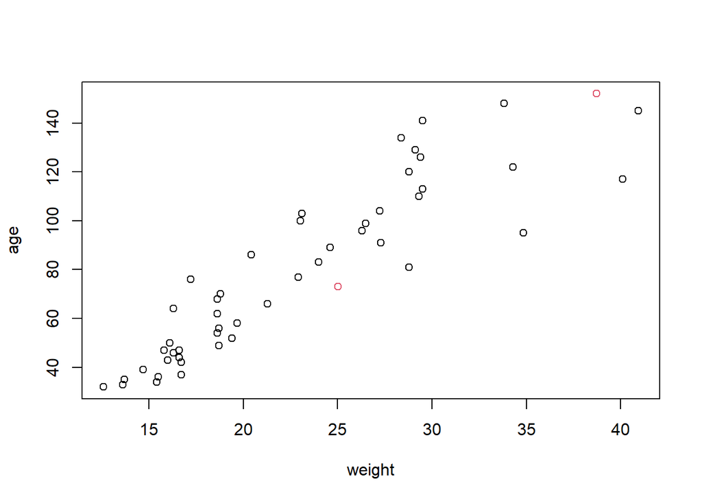

```r
colors <- rep(1,50)
colors[c(25,50)] <- 2
plot(x=weight,y=age,col=colors)
```

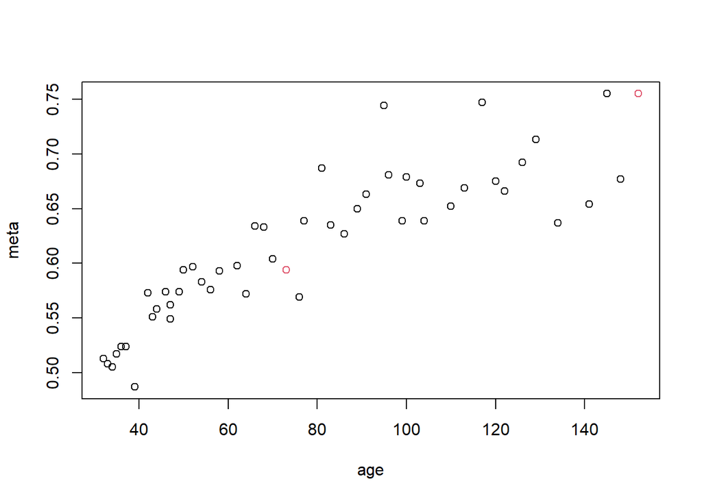

```r
plot(x=age,y=meta,col=colors)
```

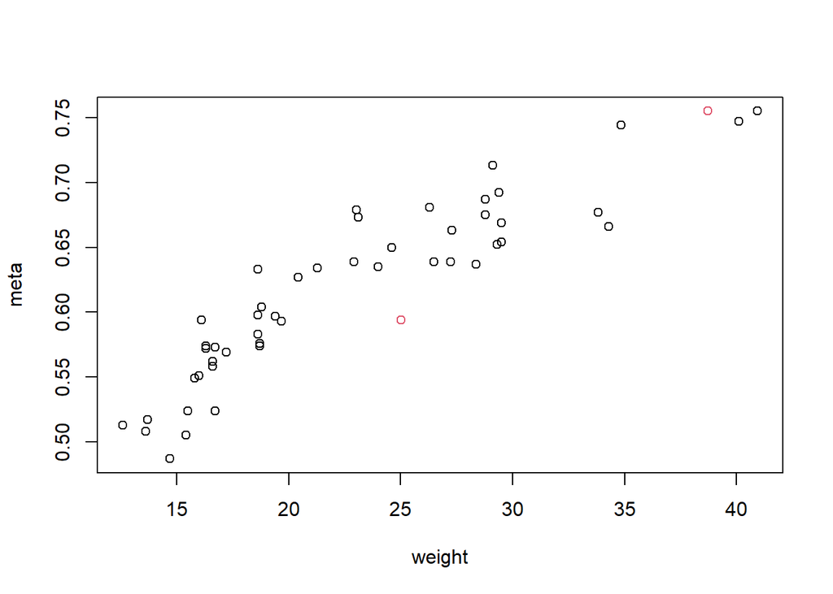

```r
plot(x=weight,y=meta,col=colors)
```

#### 5. Is there multicollinearity in the final model? If necessary adjust the

model.

Remark: If you would have added a quadratic effect of height (which is slightly more significant) instead of a quadratic effect of age, then you would have ended with the following model:

```r
modelD <- lm(meta ~ height + weight + I(height^2))
summary(modelD)
```

```
##
## Call:
## lm(formula = meta ~ height + weight + I(height^2))
##
## Residuals:
##       Min        1Q    Median        3Q       Max
## -0.056601 -0.016407  0.001866  0.011898  0.039692
##
## Coefficients:
##               Estimate Std. Error t value Pr(>|t|)
## (Intercept) -3.699e-01  1.940e-01  -1.907 0.062828 .
## height       1.307e-02  3.280e-03   3.983 0.000240 ***
## weight       6.349e-03  1.608e-03   3.949 0.000267 ***
## I(height^2) -4.939e-05  1.478e-05  -3.342 0.001658 **
## ---
## Signif. codes:  0 '***' 0.001 '**' 0.01 '*' 0.05 '.' 0.1 ' ' 1
##
## Residual standard error: 0.02266 on 46 degrees of freedom
## Multiple R-squared:  0.8985, Adjusted R-squared:  0.8919
## F-statistic: 135.8 on 3 and 46 DF,  p-value: < 2.2e-16
```

If you wouldn’t have added age as a quadratic effect, you could have ended with the following model:

```r
modelE <- lm(meta ~ height + weight + height:weight)
summary(modelE)
```

```
##
## Call:
## lm(formula = meta ~ height + weight + height:weight)
##
## Residuals:
##       Min        1Q    Median        3Q       Max
## -0.053766 -0.012749  0.003647  0.014004  0.040900
##
## Coefficients:
##                 Estimate Std. Error t value Pr(>|t|)
## (Intercept)    8.888e-02  8.966e-02   0.991  0.32671
## height         3.221e-03  7.541e-04   4.271 9.66e-05 ***
## weight         1.747e-02  6.369e-03   2.742  0.00866 **
## height:weight -8.983e-05  4.007e-05  -2.242  0.02986 *
## ---
## Signif. codes:  0 '***' 0.001 '**' 0.01 '*' 0.05 '.' 0.1 ' ' 1
##
## Residual standard error: 0.02399 on 46 degrees of freedom
## Multiple R-squared:  0.8863, Adjusted R-squared:  0.8789
## F-statistic: 119.5 on 3 and 46 DF,  p-value: < 2.2e-16
```

If you would do backward selection (assuming we don’t add a quadratic trend for the logarithm of the metabolism in terms of weight and lenght):

```r
modelFull <- lm(meta ~ height + weight + age + I(age^2) + height:weight + height:age + height:I(age^2) + weight:age + weight:I(age^2))
```

```r
step <- lm(meta ~ height + weight + age + height:age)
summary(step)
```

```
##
## Call:
## lm(formula = meta ~ height + weight + age + height:age)
##
## Residuals:
##       Min        1Q    Median        3Q       Max
## -0.054167 -0.012236  0.000779  0.011466  0.037517
##
## Coefficients:
##               Estimate Std. Error t value Pr(>|t|)
## (Intercept)  1.367e-01  7.206e-02   1.897 0.064197 .
## height       2.670e-03  9.165e-04   2.913 0.005554 **
## weight       6.412e-03  1.643e-03   3.903 0.000315 ***
## age          3.599e-03  1.268e-03   2.839 0.006774 **
## height:age  -2.691e-05  8.272e-06  -3.253 0.002168 **
## ---
## Signif. codes:  0 '***' 0.001 '**' 0.01 '*' 0.05 '.' 0.1 ' ' 1
##
## Residual standard error: 0.02272 on 45 degrees of freedom
## Multiple R-squared:  0.9002, Adjusted R-squared:  0.8913
## F-statistic: 101.5 on 4 and 45 DF,  p-value: < 2.2e-16
```

The order in which we remove terms (do this yourself as an exercise!): height:age^2, height:weight, weight:I(age^2), I(age^2), weight:age. Remark that you should never remove main effects when their corresponding quadratic or interaction terms are still in the model! The intercept should always stay in the model!

There are a lot of different solutions. Why is this? What is wrong?

```r
cor(height, weight)
```

```
## [1] 0.9475074
```

```r
cor(height,age)
```

```
## [1] 0.9618876
```

```r
cor(weight,age)
```

```
## [1] 0.9083974
```

Aha…

```r
library(faraway)
vif(model8)
```

```
##    weight       age  I(age^2)
##  5.725772 35.923574 30.474279
```

```r
vif(modelE)
```

```
##        height        weight height:weight
##      14.14937     187.06225     235.37789
```

```r
vif(step)
```

```
##     height     weight        age height:age
##   23.29206   13.86616  191.50213  213.96186
```

VIF stands for the Variance Inflation Factor. The VIF for the k-th coefficient in the regression model is defined as: $VIF = (1-R_k^2)^{-1}$

Here $R_k^2$ is the multiple correlation coefficient of a linear regression with the k-th predictor on all other predictors in the model. The VIF has as a property that she is equal to 1 if the k-th predictor is not linearly associated with th eother predictors in the model (so when the k-the predictor is perfectly uncorrelated with the other predictors). The VIF is larger than 1 in all other cases. The VIF also expresses how much larger the observed variance on the estimation of the k-the coefficient is compared with when all predictors would be independent. The larger the VIF, the less stable the estimates will be. We talk about strong multicollinearity when the VIF is larger than 10.

We notice an extremely high multicollinearity!

As the height is explaining most of the variance in the response variable, we will propose a model with only this variable. To do: validate this model again (residual plots, Cook’s Distance, …).

```r
#Old model:
summary(finalmodel)
```

```
##
## Call:
## lm(formula = meta ~ weight + age + I(age^2))
##
## Residuals:
##       Min        1Q    Median        3Q       Max
## -0.048337 -0.011677  0.000364  0.014493  0.038488
##
## Coefficients:
##               Estimate Std. Error t value Pr(>|t|)
## (Intercept)  3.498e-01  2.111e-02  16.571  < 2e-16 ***
## weight       6.363e-03  1.054e-03   6.038 2.54e-07 ***
## age          2.786e-03  5.482e-04   5.083 6.65e-06 ***
## I(age^2)    -1.312e-05  2.854e-06  -4.598 3.34e-05 ***
## ---
## Signif. codes:  0 '***' 0.001 '**' 0.01 '*' 0.05 '.' 0.1 ' ' 1
##
## Residual standard error: 0.02269 on 46 degrees of freedom
## Multiple R-squared:  0.8983, Adjusted R-squared:  0.8917
## F-statistic: 135.5 on 3 and 46 DF,  p-value: < 2.2e-16
```

```r
#New model:
finalmodel2 <- lm(meta ~ height)
summary(finalmodel2)
```

```
##
## Call:
## lm(formula = meta ~ height)
##
## Residuals:
##      Min       1Q   Median       3Q      Max
## -0.06732 -0.01649  0.00417  0.01468  0.06254
##
## Coefficients:
##              Estimate Std. Error t value Pr(>|t|)
## (Intercept) 0.1702821  0.0264531   6.437 5.37e-08 ***
## height      0.0037374  0.0002185  17.103  < 2e-16 ***
## ---
## Signif. codes:  0 '***' 0.001 '**' 0.01 '*' 0.05 '.' 0.1 ' ' 1
##
## Residual standard error: 0.02615 on 48 degrees of freedom
## Multiple R-squared:  0.859,  Adjusted R-squared:  0.8561
## F-statistic: 292.5 on 1 and 48 DF,  p-value: < 2.2e-16
```

**Compare the $R^2$ of the last “final” model. What do you see?**

…

Another option would be to center the predictors around zero (this is advised when you include interaction and quadratic term in the model).

```r
c.height <- scale(height,center=TRUE,scale=FALSE)
c.weight <- scale(weight,center=TRUE,scale=FALSE)
c.age <- scale(age,center=TRUE,scale=FALSE)
model7B <- lm(meta ~ c.height + c.weight + c.age + I(c.age^2))
```

```r
summary(model7B)
```

```
##
## Call:
## lm(formula = meta ~ c.height + c.weight + c.age + I(c.age^2))
##
## Residuals:
##      Min       1Q   Median       3Q      Max
## -0.04942 -0.01177  0.00030  0.01366  0.03857
##
## Coefficients:
##               Estimate Std. Error t value Pr(>|t|)
## (Intercept)  6.335e-01  5.862e-03 108.063  < 2e-16 ***
## c.height     3.625e-04  1.262e-03   0.287 0.775175
## c.weight     6.017e-03  1.608e-03   3.742 0.000515 ***
## c.age        5.856e-04  4.588e-04   1.276 0.208361
## I(c.age^2)  -1.234e-05  3.969e-06  -3.108 0.003257 **
## ---
## Signif. codes:  0 '***' 0.001 '**' 0.01 '*' 0.05 '.' 0.1 ' ' 1
##
## Residual standard error: 0.02292 on 45 degrees of freedom
## Multiple R-squared:  0.8985, Adjusted R-squared:  0.8895
## F-statistic:  99.6 on 4 and 45 DF,  p-value: < 2.2e-16
```

```r
vif(model7B)
```

```
##   c.height   c.weight      c.age I(c.age^2)
##  43.408347  13.065612  24.666648   2.313603
```

The VIF is now smaller for some of the effects, but still too high. Centering doesn’t improve much in this case, but it can be a solution in other cases. It is always worth trying!